# Untersuchungen zur koronaren Herzkrankheit (t-tests)

# Untersuchungen zur koronaren Herzkrankheit

In diesem Abschnitt sollen Daten von Probanden bzw. Patienten auf das Risiko für koronare Herzkrankheit untersucht werden. Dies ist eine Erkrankung der Herzkranzgefäße (Koronararterien), die sich durch Ablagerungen in den Gefäßwänden verengen. Der Original-Herz-Datensatz ist unter

- https://archive.ics.uci.edu/ml/datasets/Heart+Disease

beschrieben. Wir nutzen eine konsolidierte CSV-Datei, die bereits Header enthält. Download unter:

- https://oc.informatik.hs-mannheim.de/s/wyzFq34K9HiNjXR/download

Die Datei enthält 13 Merkmale, die einen Einfluss auf eine koronare Herzkrankheit haben können. Das 14. Merkmal `goal` (im Original auch `num`) ist die Diagnose (Klassifizierung). Der Wert ist 0, falls keine krankhafte Verengung der Gefäße vorliegt, oder 1, 2, 3 oder 4, falls – je nach Stärke – eine krankhafte Verengung der Gefäße vorliegt. Unter

- https://archive.ics.uci.edu/ml/machine-learning-databases/heart-disease/heart-disease.names

finden Sie eine Beschreibung aller Attribute. Hier ist eine Zusammenfassung. Wir benötigen insbesondere die Merkmale `sex`, `trestbps`, `chol` und `goal`.

[output not shown]

## Einlesen der Herz-Daten

Lesen Sie die Datei aus der URL als Data Frame zur weiteren Bearbeitung ein. Überlegen Sie, ob sie Faktoren sinnvoll einsetzen können. Geben Sie die ersten drei Zeilen und fünf Spalten aus[^2]:

```r
# Ihre Lösung:
file = url('https://oc.informatik.hs-mannheim.de/s/wyzFq34K9HiNjXR/download')
df = data.frame(read.csv(file, sep = ',', header = TRUE, stringsAsFactors = TRUE))
df$sex = factor(df$sex)
df$goal = factor(df$goal)

df[1:3,1:5]
```

```
##   age sex cp trestbps chol
## 1  63   1  1      145  233
## 2  67   1  4      160  286
## 3  67   1  4      120  229
```

## Cholesterin im Vergleich Männer/Frauen

Nun sollen die Cholerstin-Werte untersucht werden – zunächst im Vergleich Männer zu Frauen.

### Überblick über Cholesterin-Daten

Verschaffen Sie sich einen Überblick, indem Sie ein Boxplot für das Cholesterin gruppiert nach dem Geschlecht plotten.

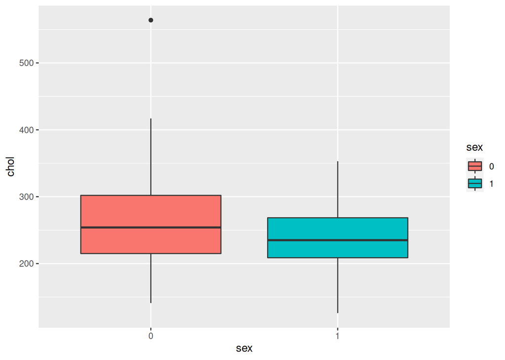

```r
# Ihre Lösung:
ggplot(df) +
  geom_boxplot(aes(sex, chol, fill=sex))
```

### Konfidenz-Intervall

Berechnen Sie das Konfidenz-Intervall (Niveau 95%) für den Cholesterin-Level jeweils für Männer und Frauen.

#### Tabelle

Geben Sie das Ergebnis als `kable`-Tabelle aus:

```r
# Ihre Lösung:
t_m = t.test(df[df$sex == 1,]$chol, conf.level = 0.95, alternative = 'two.sided')
t_f = t.test(df[df$sex == 0,]$chol, conf.level = 0.95, alternative = 'two.sided')
result = data.frame(t_m$conf.int, t_f$conf.int)
rownames(result) = c('lower', 'upper')
colnames(result) = c('male', 'female')
kable(result)
```

|  | male | female |
| --- | --- | --- |
| lower | 233.7432 | 248.6722 |
| upper | 245.4607 | 274.8330 |

#### Überlappung?

Überlappen sich die Bereiche?

Antwort: Nein

## Cholesterin im Vergleich zur Erkrankung

Nun sollen die Cholesterin-Werte in Abhängigkeit der Diagnose untersucht werden.

### Überblick über Cholesterin-Daten

Verschaffen Sie sich einen Überblick, indem Sie ein Boxplot für das Cholesterin gruppiert nach der Diagnose plotten.

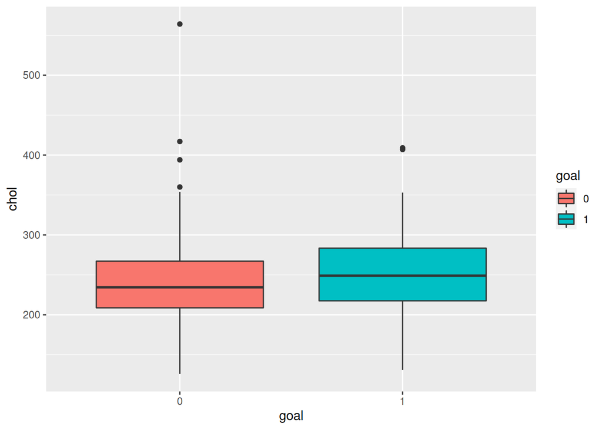

```r
# Ihre Lösung:
df$goal = factor(sapply(df$goal, function(x) if (x == 0) 0 else 1))
ggplot(df) +
  geom_boxplot(aes(goal, chol, fill = goal))
```

### Konfidenz-Intervall

Berechnen Sie die Konfidenzintervalle für beide Gruppen und geben Sie das Ergebnis als `kable`-Tabelle aus:

```r
# Ihre Lösung:
t_negative = t.test(df[df$goal == 0,]$chol, conf.level = 0.95, alternative = 'two.sided')
t_positive = t.test(df[df$goal == 1,]$chol, conf.level = 0.95, alternative = 'two.sided')
result = data.frame(t_negative$conf.int, t_positive$conf.int)
rownames(result) = c('lower', 'upper')
colnames(result) = c('negative', 'positive')
kable(result)
```

|  | negative | positive |
| --- | --- | --- |
| lower | 234.3977 | 243.1752 |
| upper | 250.8828 | 259.7744 |

### Test

Es sieht so aus, als ob der Cholesterin-Wert bei den erkrankten Patienten höher ist als bei den nicht bzw. weniger erkrankten. Überprüfen Sie das mit einem Hypothesen-Test.

#### Wie lauten die Hypothesen?

Formulieren Sie die Hypothesen ($H_0$ und $H_1$).

#### Testanwendung

Wenden Sie den Test mit R an. Was ist das Ergebnis?

```r
# Ihre Lösung:
t.test(df[df$goal == 0,]$chol, df[df$goal == 1,]$chol, conf.level = 0.95, mu = 0, alternative = 'less')
```

```
##
##  Welch Two Sample t-test
##
## data:  df[df$goal == 0, ]$chol and df[df$goal == 1, ]$chol
## t = -1.4924, df = 298.64, p-value = 0.06832
## alternative hypothesis: true difference in means is less than 0
## 95 percent confidence interval:
##       -Inf 0.9327489
## sample estimates:
## mean of x mean of y
##  242.6402  251.4748
```

Da p größer als 0,05 ist, kann $H_0$ nicht verworfen werden.

## Systolischer Ruheblutdruck

Der systolische Blutdruck liegt beim gesunden Menschen bei ca. 120 mmHg.

### Überblick über Blutdruck

#### Plot

Verschaffen Sie sich einen Überblick, indem Sie ein Boxplot für den Blutdruck in Ruhe gruppiert nach dem Geschlecht plotten.

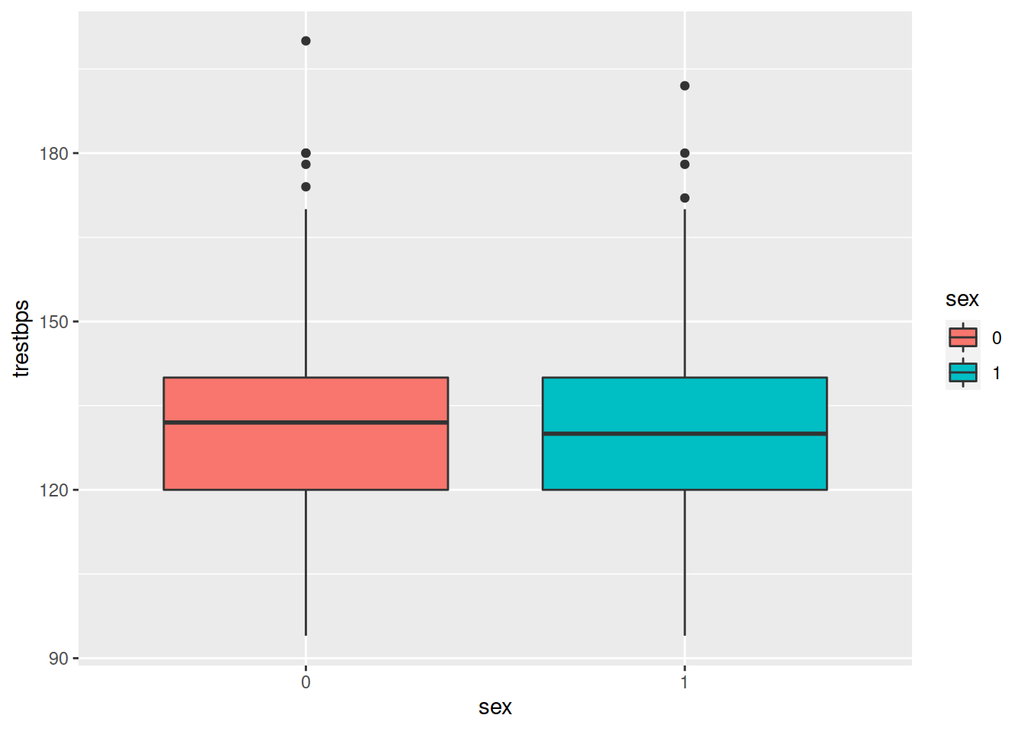

```r
# Ihre Lösung:
ggplot(df) +
  geom_boxplot(aes(sex, trestbps, fill = sex))
```

#### Normalverteilt?

Kann überhaupt davon ausgegangen werden, dass die Daten normalverteilt sind? Antwort: Ja, siehe zentraler Grenzwertsatz.

### Konfidenzintervalle nach Erkrankung

Berechnen Sie die Konfidenzintervalle für den Ruheblutdruck aufgeschlüsselt nach der Diagnose (erkrankt/nicht erkrankt) und geben Sie das Ergebnis als `kable`-Tabelle aus:

```r
# Ihre Lösung:
t_negative = t.test(df[df$goal == 0,]$trestbps, conf.level = 0.95, alternative = 'two.sided')
t_positive = t.test(df[df$goal == 1,]$trestbps, conf.level = 0.95, alternative = 'two.sided')
result = data.frame(t_negative$conf.int, t_positive$conf.int)
rownames(result) = c('lower', 'upper')
colnames(result) = c('negative', 'positive')
kable(result)
```

|  | negative | positive |
| --- | --- | --- |
| lower | 126.7514 | 131.4205 |
| upper | 131.7486 | 137.7161 |

### Test, ob Kranke höheren Ruhe-Blutdruck haben

Überprüfen Sie mit einem Hypothesen-Test, ob Erkrankte einen höheren Ruhe-Blutdruck haben als gesunde Probanden.

#### Wie lauten die Hypothesen?

Formulieren Sie die Hypothesen ($H_0$ und $H_1$).

#### Testanwendung

Wenden Sie den Test mit R an. Was ist das Ergebnis?

```r
# Ihre Lösung:
t.test(df[df$goal == 0,]$trestbps, df[df$goal == 1,]$trestbps, conf.level = 0.95, alternative = 'less')
```

```
##
##  Welch Two Sample t-test
##
## data:  df[df$goal == 0, ]$trestbps and df[df$goal == 1, ]$trestbps
## t = -2.6152, df = 274.64, p-value = 0.004705
## alternative hypothesis: true difference in means is less than 0
## 95 percent confidence interval:
##       -Inf -1.962045
## sample estimates:
## mean of x mean of y
##  129.2500  134.5683
```

Da p kleiner als 0,05 ist, wird $H_0$ verworfen. Der Ruhe-Blutdruck bei Erkrankten ist somit höher als bei Gesunden.

[^1]: ST depression refers to a finding on an electrocardiogram, wherein the trace in the ST segment is abnormally low below the baseline.
[^2]: Möglicherweise kommt es zu einem Fehler beim Einlesen des ersten Attributs (`age`). Manuelles Umbenennen hilft.